# Social Network Analysis Demonstration

The LASER Team

August 11, 2021

Welcome to the *social network analysis* demo! To complete this, click the green arrows to the right of each code chunk.

## 1. Loading, Setting Up

In this section, we load packages with the `library()` function and read data using the `read_csv()` function.

- `d` refers to the data we loaded on teachers’ relations
- `u` refers to “user”-level data (e.g., on teachers’ years of experience)

```r
set.seed(0811)

library(tidyverse)
library(tidygraph)
library(ggraph)
library(here)

d <- read_csv(here('data', 'teacher-network-data-relations.csv'))
u <- read_csv(here('data', 'teacher-network-data-users.csv'))
```

#### **Your Turn** **⤵**

Run the following two code chunks to take a *glimpse* at your data. Below, add a few notes on what you *notice* and *wonder*

```r
glimpse(d)
```

```
## Rows: 12
## Columns: 4
## $ name           <chr> "Mikayla", "Dylan", "Ilyaas", "Wayne", "Kaitlyn", "Camron", "Melody", "Lakota", "Stephanie", "Jessica", "Faseeha", "Pa…
## $ most_helpful_1 <chr> "Dylan", "Faseeha", "Mikayla", "Melody", "Melody", "Melody", "Wayne", "Camron", "Jessica", "Faseeha", "Kaitlyn", "Step…
## $ most_helpful_2 <chr> NA, NA, "Melody", "Faseeha", NA, "Lakota", "Faseeha", NA, "Patrick", "Melody", "Mikayla", "Jessica"
## $ most_helpful_3 <chr> NA, NA, NA, NA, NA, NA, NA, NA, "Melody", NA, "Melody", NA
```

```r
glimpse(u)
```

```
## Rows: 12
## Columns: 3
## $ name                <chr> "Mikayla", "Dylan", "Ilyaas", "Wayne", "Kaitlyn", "Camron", "Melody", "Lakota", "Stephanie", "Jessica", "Faseeha"…
## $ years_of_experience <dbl> 1, 27, 4, 7, 5, 0, 10, 2, 3, 2, 18, 1
## $ subject             <chr> "Chemistry", "Biology", "Biology", "Biology", "Biology", "Chemistry", "Chemistry", "Chemistry", "Biology", "Biolo…
```

What do you *notice* and/or *wonder* about this data? Add a note or two below!

## 2. Preparing Data

In this section, we prepare our data to be in edgelist format.

#### **Your Turn** **⤵**

```r
d_long <- d %>%
  pivot_longer(most_helpful_1:most_helpful_3, names_to = "nominee") %>%
  mutate(nominee_rank = str_sub(nominee, start = -1),
         nominee_rank = as.integer(nominee_rank)) %>%
  select(-nominee) %>%
  filter(!is.na(value))

d_long
```

```
## # A tibble: 22 x 3
##    name    value   nominee_rank
##    <chr>   <chr>          <int>
##  1 Mikayla Dylan              1
##  2 Dylan   Faseeha            1
##  3 Ilyaas  Mikayla            1
##  4 Ilyaas  Melody             2
##  5 Wayne   Melody             1
##  6 Wayne   Faseeha            2
##  7 Kaitlyn Melody             1
##  8 Camron  Melody             1
##  9 Camron  Lakota             2
## 10 Melody  Wayne              1
## # … with 12 more rows
```

What is different about the edgelist data now? Add one or more observations (you can add additional observations by adding more dashes):

## 3. Creating a Graph ‘Object’ and Preparing to Visualize the Network

This next step is key in that we use the `tbl_graph()` function to create a network “object”; if that sounds a bit vague, it should! An “object” refers to a type of data in R. Here, it’s one that is specific to the packages we are using for social network analysis.

Here, we create a network object with only the edgelist.

```r
g <- tbl_graph(edges = d_long)

g
```

```
## # A tbl_graph: 12 nodes and 22 edges
## #
## # A directed simple graph with 1 component
## #
## # Node Data: 12 x 1 (active)
##   name
##   <chr>
## 1 Mikayla
## 2 Dylan
## 3 Faseeha
## 4 Ilyaas
## 5 Melody
## 6 Wayne
## # … with 6 more rows
## #
## # Edge Data: 22 x 3
##    from    to nominee_rank
##   <int> <int>        <int>
## 1     1     2            1
## 2     2     3            1
## 3     4     1            1
## # … with 19 more rows
```

#### **Your Turn** **⤵**

Let’s create this object again, but also adding *nodes* information, or the user-level information we also loaded earlier on.

```r
g <- tbl_graph(edges = d_long, nodes = u)

g
```

```
## # A tbl_graph: 12 nodes and 22 edges
## #
## # A directed simple graph with 1 component
## #
## # Node Data: 12 x 3 (active)
##   name    years_of_experience subject
##   <chr>                 <dbl> <chr>
## 1 Mikayla                   1 Chemistry
## 2 Dylan                    27 Biology
## 3 Ilyaas                    4 Biology
## 4 Wayne                     7 Biology
## 5 Kaitlyn                   5 Biology
## 6 Camron                    0 Chemistry
## # … with 6 more rows
## #
## # Edge Data: 22 x 3
##    from    to nominee_rank
##   <int> <int>        <int>
## 1     1     2            1
## 2     2    11            1
## 3     3     1            1
## # … with 19 more rows
```

```r
g <- g %>%
  mutate(popularity = centrality_degree(mode = 'in')) %>%
  activate("edges") %>%
  mutate(nominee_rank = as.factor(nominee_rank))

g
```

```
## # A tbl_graph: 12 nodes and 22 edges
## #
## # A directed simple graph with 1 component
## #
## # Edge Data: 22 x 3 (active)
##    from    to nominee_rank
##   <int> <int> <fct>
## 1     1     2 1
## 2     2    11 1
## 3     3     1 1
## 4     3     7 2
## 5     4     7 1
## 6     4    11 2
## # … with 16 more rows
## #
## # Node Data: 12 x 4
##   name    years_of_experience subject   popularity
##   <chr>                 <dbl> <chr>          <dbl>
## 1 Mikayla                   1 Chemistry          2
## 2 Dylan                    27 Biology            1
## 3 Ilyaas                    4 Biology            0
## # … with 9 more rows
```

What do you notice about the `g` network object? How does it appear different from either the edgelist or the user-level data we loaded?

## 4. Creating and Refining a Network Visualization

Perhaps our question has to do with who is most central (and, possibly, the most influential) within our network.

Let’s start with a simple visualization of our network using `geom_edge_fan()` and `geom_node_point()`.

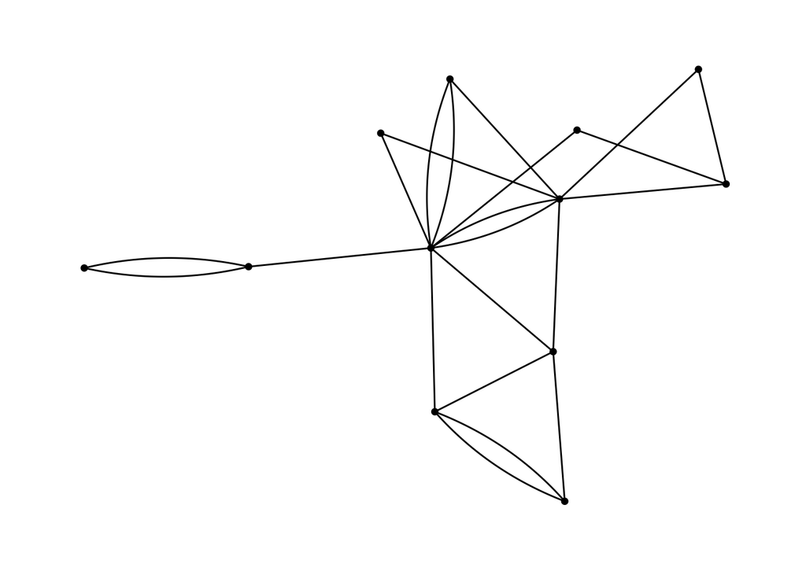

```r
ggraph(g, layout = 'kk') +
  geom_edge_fan() +
  geom_node_point() +
  theme_graph()
```

We can enhance this visualization in numerous ways, such as by:

- Sizing the points based on popularity, or in-degree centrality (how many times a person was a nominee)
- Coloring the points by subject
- Changing the hue of the edges based upon the order in which one was nominated

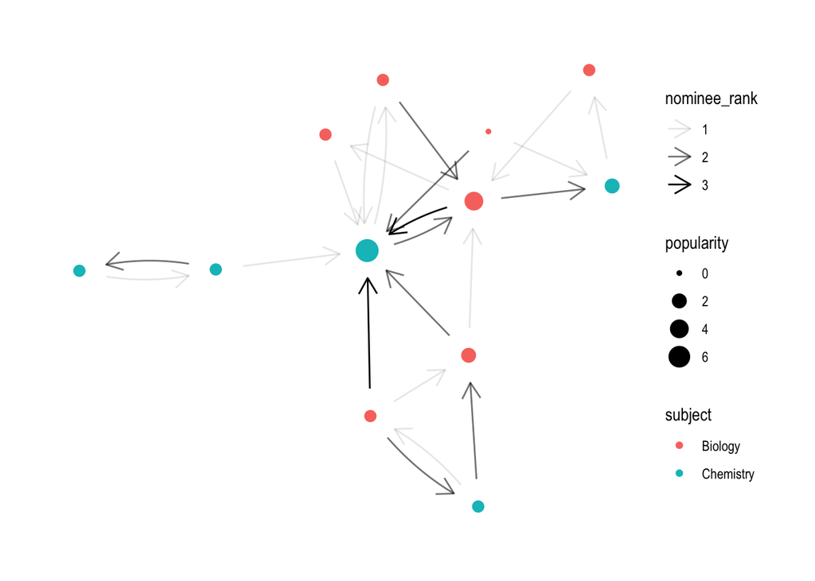

```r
ggraph(g, layout = 'kk') +
  geom_edge_fan(aes(alpha = nominee_rank),
                arrow = arrow(length = unit(4, 'mm')),
                start_cap = circle(6, 'mm'),
                end_cap = circle(6, 'mm')) +
  geom_node_point(aes(size = popularity, color = subject)) +
  theme_graph()
```

We might wish instead to size the points by years of experience, as we do below.

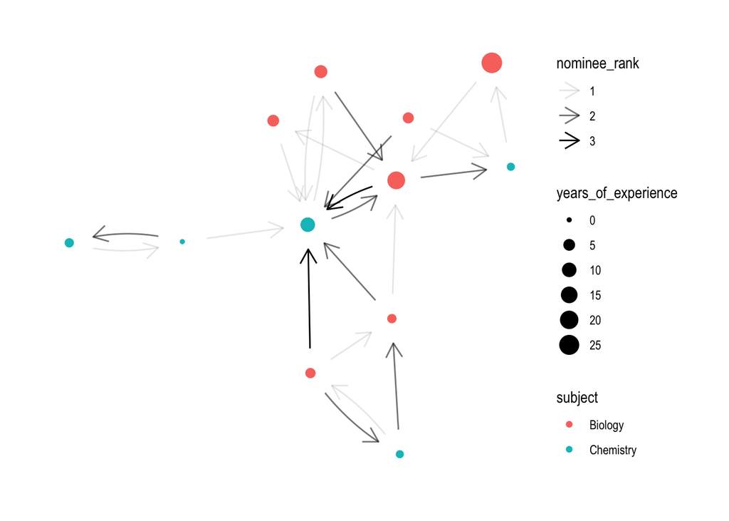

```r
ggraph(g, layout = 'kk') +
  geom_edge_fan(aes(alpha = nominee_rank),
                arrow = arrow(length = unit(4, 'mm')),
                start_cap = circle(6, 'mm'),
                end_cap = circle(6, 'mm')) +
  geom_node_point(aes(size = years_of_experience, color = subject)) +
  theme_graph()
```

We can use names (if anonymized or otherwise ethically appropriate for our analysis), as below.

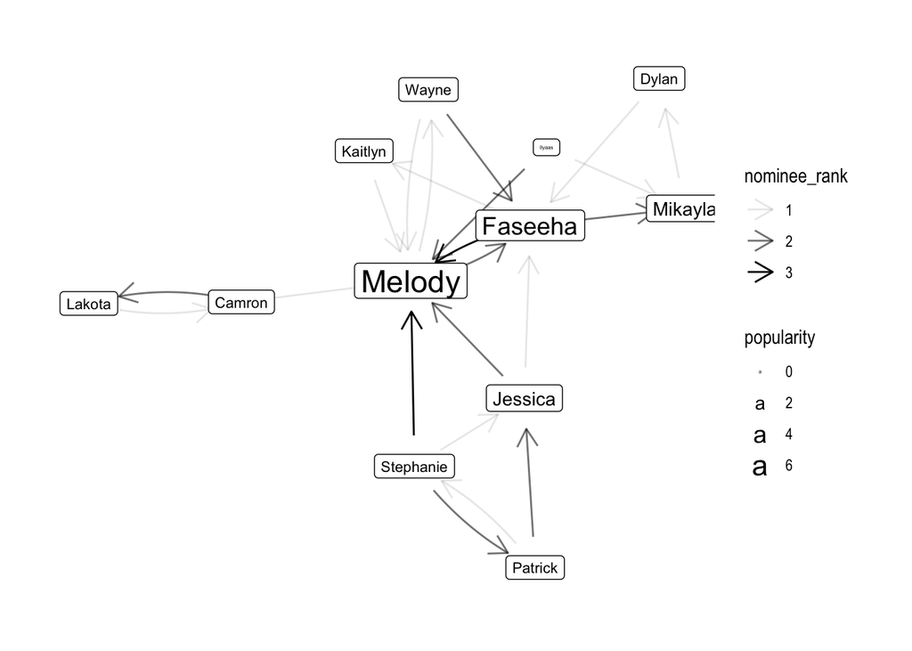

```r
ggraph(g, layout = 'kk') +
  geom_edge_fan(aes(alpha = nominee_rank),
                arrow = arrow(length = unit(4, 'mm')),
                start_cap = circle(6, 'mm'),
                end_cap = circle(6, 'mm')) +
  geom_node_label(aes(label = name, size = popularity)) +
  theme_graph()
```

Lastly, we can identify sub-groups within our network and use color to indicate which individuals are a part of which sub-groups, as below.

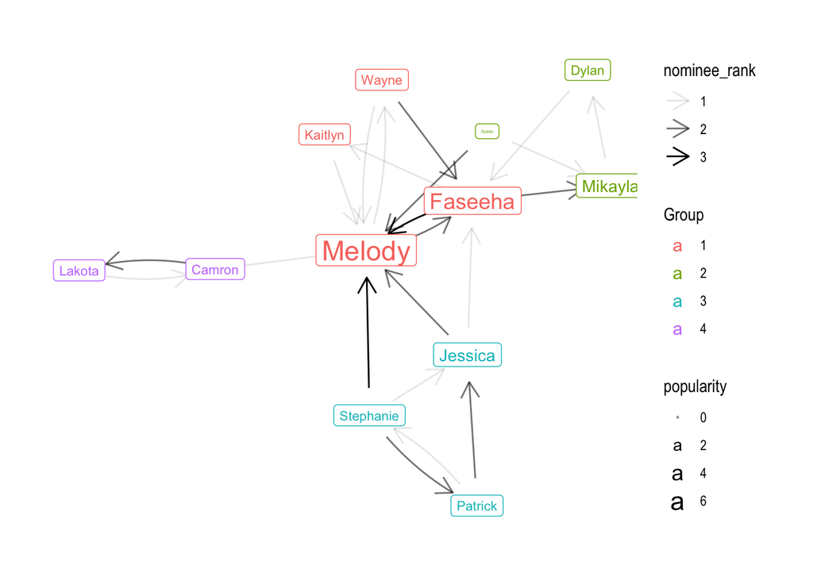

```r
g %>%
  activate(nodes) %>%
  mutate(group = group_spinglass()) %>%
  ggraph(layout = 'kk') +
  geom_edge_fan(aes(alpha = nominee_rank),
                arrow = arrow(length = unit(4, 'mm')),
                start_cap = circle(6, 'mm'),
                end_cap = circle(6, 'mm')) +
  geom_node_label(aes(label = name, size = popularity, color = as.factor(group))) +
  theme_graph() +
  scale_color_discrete("Group", type = "qual")
```

#### **Your Turn** **⤵**

Which visualization is most helpful for understanding who may be influential in the network? Why?

## 5. Calculating Descriptive Statistics

Finally, we can calculate a range of network statistics, as below.

```r
g <- g %>%
  activate("nodes") %>%
  rename(in_degree_centrality = popularity) %>%
  mutate(out_degree = centrality_degree(mode = 'out')) %>%
  mutate(betweenness_centrality = centrality_betweenness()) %>%
  mutate(centrality_eigen = centrality_eigen())

g %>%
  as_tibble() %>%
  skimr::skim()
```

Data summary

| Name | Piped data |
| --- | --- |
| Number of rows | 12 |
| Number of columns | 7 |
| _______________________ |  |
| Column type frequency: |  |
| character | 2 |
| numeric | 5 |
| ________________________ |  |
| Group variables | None |

**Variable type: character**

| skim_variable | n_missing | complete_rate | min | max | empty | n_unique | whitespace |
| --- | --- | --- | --- | --- | --- | --- | --- |
| name | 0 | 1 | 5 | 9 | 0 | 12 | 0 |
| subject | 0 | 1 | 7 | 9 | 0 | 2 | 0 |

**Variable type: numeric**

| skim_variable | n_missing | complete_rate | mean | sd | p0 | p25 | p50 | p75 | p100 | hist |
| --- | --- | --- | --- | --- | --- | --- | --- | --- | --- | --- |
| years_of_experience | 0 | 1 | 6.67 | 8.14 | 0.00 | 1.75 | 3.50 | 7.75 | 27 | ▇▂▁▁▁ |
| in_degree_centrality | 0 | 1 | 1.83 | 1.90 | 0.00 | 1.00 | 1.00 | 2.00 | 7 | ▇▂▁▁▁ |
| out_degree | 0 | 1 | 1.83 | 0.72 | 1.00 | 1.00 | 2.00 | 2.00 | 3 | ▅▁▇▁▂ |
| betweenness_centrality | 0 | 1 | 7.00 | 10.44 | 0.00 | 0.00 | 2.50 | 7.75 | 31 | ▇▂▁▁▂ |
| centrality_eigen | 0 | 1 | 0.44 | 0.27 | 0.11 | 0.26 | 0.34 | 0.56 | 1 | ▇▅▃▁▃ |

We could also group our data by either years of experience or subject to begin to understand differences in centrality (and, potentially, influence), as below.

```r
g %>%
  as_tibble() %>%
  group_by(subject) %>%
  select(-name) %>%
  summarize(mean_in_degree_centrality = mean(in_degree_centrality),
            sd_in_degree_centrality = sd(in_degree_centrality))
```

```
## # A tibble: 2 x 3
##   subject   mean_in_degree_centrality sd_in_degree_centrality
##   <chr>                         <dbl>                   <dbl>
## 1 Biology                        1.43                    1.27
## 2 Chemistry                      2.4                     2.61
```

```r
g %>%
  as_tibble() %>%
  mutate(high_experience = if_else(years_of_experience > 5, 1, 0)) %>%
  group_by(high_experience) %>%
  summarize(mean_in_degree_centrality = mean(in_degree_centrality),
            sd_in_degree_centrality = sd(in_degree_centrality))
```

```
## # A tibble: 2 x 3
##   high_experience mean_in_degree_centrality sd_in_degree_centrality
##             <dbl>                     <dbl>                   <dbl>
## 1               0                      1.12                   0.641
## 2               1                      3.25                   2.87
```

#### **Your Turn** **⤵**

Based on the descriptive statistics, what can we say is associated with an individual being more (or less) central in the network?